# Analítica Computacional

Sesión #5: Regresión Poisson

Autor/a

Afiliación

[Jorge I. Vélez, PhD](https://jorgeivanvelez.netlify.app/)

Universidad del Norte, Barranquilla

Fecha de publicación

12 de abril de 2024

Resumen

En esta práctica de `R` trabajaremos (1) la sintaxis del modelo de Regresión Poisson y (2) cómo estimar e interpretar el modelo.

## Introducción

La Regresión Poisson es útil cuando se tiene una variable aleatoria respuesta $Y$ que representa conteos por unidad de distancia, área, volúmen o tiempo, y es de interés predecir la el número esperado de dichos conteos a partir de un conjunto de factores controlables independientes $X_1, X_2, \ldots, X_k$.

En cuanto a la variable respuesta $Y$, el modelo probabilístico es $Y \sim \text{Poisson}(\lambda)$, con $\lambda>0$. Así,
$$E[Y|X_1, X_2, \ldots, X_k] = \text{Var}[Y|X_1, X_2, \ldots, X_k] = \lambda.$$

A partir de una muestra de tamaño $n$, el modelo de Regresión Poisson estimado es:

$$\begin{align}
\log\left(\hat{\lambda}\right) = \hat{\beta}_0 + \hat{\beta}_1x_1 + \hat{\beta}_2x_2 + \cdots +\hat{\beta}_kx_k
\end{align}$$

donde $\hat\lambda$ es el número *esperado* de conteos o la *tasa* a la que ocurre el evento de interés. A partir de la expresión anterior, es fácil llegar a que

$$\begin{equation}
\hat\lambda = e^{\hat{\beta}_0 + \hat{\beta}_1x_1 + \hat{\beta}_2x_2 + \cdots +\hat{\beta}_kx_k}
\end{equation}$$

Por lo tanto, $Y \sim \text{Poisson}(\hat{\lambda})$. A partir de esta expresión es posible calcular, por ejemplo, $P(Y = 3 | X_1, X_2, \ldots, X_k)$ ua partir del valor de $\hat{\lambda}$.

## Paquetes

En esta práctica utilizaremos funciones de los paquetes `lmtest`, `AER` y `ggplot2`.

```r
## verificar disponibilidad de lmtest
if(!require(lmtest)) install.packages('lmtest')
require(lmtest)

## verificar disponibilidad de AER
if(!require(AER)) install.packages('AER')
require(AER)

## verificar disponibilidad de ggplot2
if(!require(ggplot2)) install.packages('ggplot2')
require(ggplot2)
```

## *Caribbean Eggs*

Caribbean Eggs, Inc. produce canastas de huevos de 6, 12, 18 y 30 unidades en sus granjas avícolas ubicadas en Sabanalarga, Atlántico. Las [gallinas ponedoras](https://i0.wp.com/www.corpmontana.com/blog/wp-content/uploads/2022/10/alimento-para-pollos-scaled.jpg?resize=1280%2C640&ssl=1) se alimentan con tres tipos de dieta (`A`, `B` o `C`) y suplementos vitamínicos $x_1$ y $x_2$, ambos en ml/día. Después de un estricto proceso de seguimiento y control durante una semana, se registró el número de huevos producidos por 20 gallinas (i.e., galpón) por día.

Los datos son los siguientes:

```r
## leer datos
url <- 'https://www.dropbox.com/scl/fi/7z5obl6hincugvxx44jdq/eggs.txt?rlkey=oz3p4518ylsd3leozeud0pof2&dl=1'
d <- read.table(url, header = TRUE)
d$diet <- LETTERS[d$diet]
head(d)
```

```
   y x1 x2 diet
1  8  6  3    B
2  4  6  3    C
3  5  6  3    B
4  8  6  3    B
5 11  6  1    C
6  3  4  1    B
```

La distribución del número de huevos producidos/galpón en 1 semana:

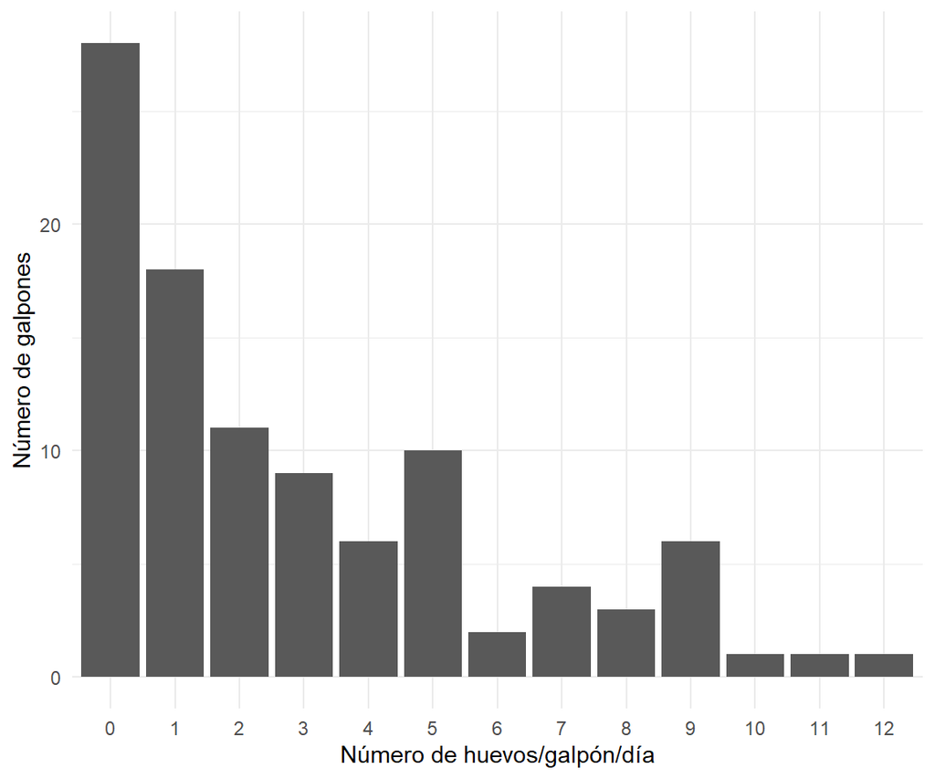

```r
## barplot con ggplot2
d0 <- as.data.frame(table(d$y))
ggplot(d0, aes(x = Var1, y = Freq)) +
  geom_bar(stat = 'identity') +
  xlab('Número de huevos/galpón/día') +
  ylab('Número de galpones') +
  theme_minimal()
```

[Aquí](https://r-graph-gallery.com/218-basic-barplots-with-ggplot2.html) hay más información sobre cómo utilizar `ggplot2` para construir el gráfico de barras

Puesto que trabajamos con conteos, una distribución de probabilidad posible que describe la variable $Y$ es $Y\sim \text{Poisson}(\lambda)$, $\lambda>0$. A partir de la muestra, se obtiene que

$$\hat\lambda = \frac{1}{100}\sum_{i=1}^{100}y_i = 2.92$$

Sin embargo, observe que la estimación de $\lambda$ no tienen en cuenta los suplementos $x_1$ y $x_2$, ni `diet`, lo cual sería deseable.

### Ajuste del modelo

Teniendo en cuenta las características de la variable respuesta `y`, es natural pensar que un modelo de Regresión Poisson puede llegar a ser una buena alternativa.

Este modelo puede ajustarse en `R` haciendo:

```r
## modelo de Regresión Poisson
## la funcion clave es glm --- para ayuda ver ?glm
## como la respuesta corresponde a conteos, usamos family = poisson()
fit <- glm(y ~ ., data = d, family = poisson())

# coeficientes estimados
summary(fit)
```

```
Call:
glm(formula = y ~ ., family = poisson(), data = d)

Deviance Residuals:
    Min       1Q   Median       3Q      Max
-2.9849  -0.7749  -0.1961   0.6904   1.9279

Coefficients:
            Estimate Std. Error z value Pr(>|z|)
(Intercept) -1.76268    0.30977  -5.690 1.27e-08 ***
x1           0.36320    0.04231   8.584  < 2e-16 ***
x2          -0.16693    0.07263  -2.298   0.0215 *
dietB        2.00021    0.25382   7.880 3.26e-15 ***
dietC        1.76063    0.25666   6.860 6.90e-12 ***
---
Signif. codes:  0 '***' 0.001 '**' 0.01 '*' 0.05 '.' 0.1 ' ' 1

(Dispersion parameter for poisson family taken to be 1)

    Null deviance: 339.034  on 99  degrees of freedom
Residual deviance:  96.283  on 95  degrees of freedom
AIC: 323.79

Number of Fisher Scoring iterations: 5
```

A partir de estos resultados, el modelo ajustado es:

$$\log(\hat{\lambda}) = -1.763 + 0.363x_1 - 0.167x_2 + 2D_B + 1.76D_C$$

donde $D_B$ y $D_C$ son variables indicadoras que representan el tipo de dieta que se proporciona.

### Tabla ANOVA

Para determinar si el modelo ajustado es mejor que el modelo `y ~ 1`, usamos una prueba de razón de verosimilitud (LRT en inglés). Este procedimiento es similar a realizar una Prueba de Significancia Global en Regresión Lineal Múltiple.

Aunque esta prueba esta implementada en el paquete `base` de `R`, el reporte de los resultados es más informativo cuando usamos la función `lrtest` del paquete `lmtest`:

```r
## comparación del modelos usando la LRT
## ajustamos un modelo simple
nullmodel <- glm(y ~ 1, data = d, family = poisson())

## LRT
lrtest(nullmodel, fit)
```

```
Likelihood ratio test

Model 1: y ~ 1
Model 2: y ~ x1 + x2 + diet
  #Df  LogLik Df  Chisq Pr(>Chisq)
1   1 -278.27
2   5 -156.89  4 242.75  < 2.2e-16 ***
---
Signif. codes:  0 '***' 0.001 '**' 0.01 '*' 0.05 '.' 0.1 ' ' 1
```

**Conclusión.** El modelo de Regresión Poisson que incluye las covariables $x_1, x_2$ y `diet` es significativamente mejor para explicar el número de huevos producidos por galpón a la semana que usar uno sin ellas.

### Prueba de Bondad de Ajuste

Para determinar que el modelo tiene **buen ajuste**, usamos el *Deviance*. Para más detalles, ver la sección [4.4.9](https://bookdown.org/roback/bookdown-BeyondMLR/ch-poissonreg.html#sec-PoisGOF) del texto *Beyond Multiple Linear Regression*. La idea fundamental es consiste calcular el valor $p$ de la prueba de hipótesis

$$\begin{cases}
H_0&: \text{El modelo propuesto tiene buen ajuste.} \\
H_1&: \text{El modelo propuesto NO tiene buen ajuste.}
\end{cases}$$

En este caso, el estadístico de prueba es una $\chi^2$. El valor $p$ puede cacularse fácilmente de la siguiente manera:

```r
## deviance test
with(fit, 1 - pchisq(deviance, df.residual))
```

```
[1] 0.4439492
```

Como el valor $p$ es $>0.05$, decimos que el modelo propuesto **ajusta bien** a los datos.

### Sobredispersión

El modelo de Regresión Poisson puede sufrir de [sobredispersión](https://en.wikipedia.org/wiki/Overdispersion). Este concepto se refiere a que, en la distribución Poisson, $E[Y] = \lambda < \text{Var}[Y]$, es decir, que el supuesto principal de la distribución no se cumple.

A partir del modelo de Regresión Poisson ajustado, podemos estimar $\phi$ como

$$\hat{\phi} = \frac{1}{n-p}\sum_{i=1}^n\hat{\rho}_i$$

donde $p=k+1$ y

$$\hat{\rho}_i = \frac{y_i - \hat{\lambda}_i}{\sqrt{\hat\lambda_i}}$$

corresponde a los residuales de Pearson.

Una posible solución a la sobredispersión de los datos es ajustar un modelo de Regresión Poisson con función de enlace tipo `quasipoisson` y estimar el parámetro de sobredispersión $\phi$.

En este caso,

```r
## ajuste del modelo con enlace quasipoisson
fitq <- glm(y ~ ., data = d, family = quasipoisson)

## ahora estimamos la dispersión
summary(fitq)$dispersion
```

```
[1] 0.9020937
```

Note que $\hat{\phi}$ = 0.902, lo cual indica que, al parecer, los datos **no** están sobredispersos después de incluir $x_1$, $x_2$ y `diet` para explicar el número de huevos/galpón/día.

Para estar *completamente* seguros, podemos hacer una prueba formal del tipo

$$\begin{cases}
H_0: \phi = 1 \\
H_1: \phi > 1
\end{cases}$$

En `R`, esta prueba está implementada en la función `dispersiontest` del paquete `AER`. El valor $p$ puede obtenerse haciendo

```r
## prueba para el coeficiente de dispersión
dispersiontest(fit, trafo = 1)$p.value
```

```
[1] 0.9286522
```

**Conclusión:** No hay evidencia de sobredispersión. Cuando hay sobredispersión, una alternativa al modelo de Regresión Poisson es una [Regresión Binomial Negativa](https://bookdown.org/roback/bookdown-BeyondMLR/ch-poissonreg.html#negative-binomial-modeling). Este modelo puede ajustarse en `R` con la función `glm.nb()` del paquete `MASS`.

### Exceso de ceros

Los datos provenientes de procesos de conteo podrían sufrir de [exceso de ceros](https://stats.idre.ucla.edu/stata/dae/zero-inflated-poisson-regression/). Esto se refiere, fundamentalmente, a que el número de ceros en los datos es mayor al que esperaríamos si estos siguieran, en realidad, una distribución Poisson.

Por ejemplo, si $Y\sim \text{Poisson}(\lambda)$ y tuviéramos una muestra de tamaño $n$, el número esperado de ceros sería
$$n_0 = n\,P(Y=0|\lambda) = n\,e^{-\lambda}$$
Si en la muestra de tamaño $n$ observamos que el número de ceros es $n^\prime>>>n_0$, entonces los datos están *inflados* con ceros.

En nuestro caso, tenemos 28 ceros y esperamos 5.4, por lo que *podría* existir un exceso de ceros.

Veamos si esta diferencia es estadísticamente significativa:

```r
## probando si el número de ceros esperado difiere del observado
prop.test(x = c(28, 5), n = c(100, 100),
          alternative  = 'two.sided')
```

```
    2-sample test for equality of proportions with continuity correction

data:  c(28, 5) out of c(100, 100)
X-squared = 17.565, df = 1, p-value = 2.777e-05
alternative hypothesis: two.sided
95 percent confidence interval:
 0.1221784 0.3378216
sample estimates:
prop 1 prop 2
  0.28   0.05
```

Al comparar la proporciones observadas y esperadas de ceros, observamos que hay **mayor** presencia de ceros en los datos. Por lo tanto, un modelo del tipo [Zero-inflated Poisson Regression](https://stats.idre.ucla.edu/r/dae/zip/) sería más apropiado. [Aquí](https://www.ncss.com/wp-content/themes/ncss/pdf/Procedures/NCSS/Zero-Inflated_Poisson_Regression.pdf) hay más detalles sobre la formulación matemática del modelo.

### Cálculo de $\hat{\lambda}$ e inferencia

Por simplicidad, trabajaremos con el modelo de Regresión Poisson ajustado que se encuentra en el objeto `fit`.

Recordemos $\hat{\lambda}$ es el número *esperado* de huevos/galpón/día cuando se conocen las variables $x_1,x_2$ y `diet`. En otras palabras,
$$\hat{\lambda} = f(x_1, x_2, \text{diet}).$$

A partir del modelo ajustado, el número promedio de huevos por galpón por día puede obtenerse como:

```r
## cálculo de lambdahat estimadas
lambdahat <- predict(fit, type = 'response')

## ahora incluyamos lambdahat para los 5 primeros individuos
d <- data.frame(id = 1:NROW(d), d, lambdahat)
head(d, 5)
```

```
  id  y x1 x2 diet lambdahat
1  1  8  6  3    B  6.793532
2  2  4  6  3    C  5.346241
3  3  5  6  3    B  6.793532
4  4  8  6  3    B  6.793532
5  5 11  6  1    C  7.465156
```

Así por ejemplo, cuando $x_1 = 6$, $x_2 = 3$ y se usa `diet`$= \text{B}$, esperaríamos, en promedio, obtener 6.79 huevos/galpón/día. Esto implica que $\hat{\lambda}|_{x_1=6, x_2 = 3, \text{diet} = \text{B}} = 6.79$.

Si las condiciones son $\mathbf{x}_0 = (5, 3)$ y se usa la dieta `B`, el valor de $\hat\lambda$ puede estimarse como:

```r
# que pasa cuando (5, 3, B) ?
x0 <- data.frame(x1 = 5, x2 = 3, diet = 'B')
predict(fit, newdata = x0, type = 'response', se.fit = TRUE)
```

```
$fit
       1
4.724527

$se.fit
       1
0.493738

$residual.scale
[1] 1
```

Un intervalo de confianza del 95% para $\lambda|_{x_1=5, x_2=3, \text{diet}=\text{B}}$ está dado por

$$4.725 \pm 1.96\times0.494 = (3.76, 5.69)$$

### Cálculo de probabilidades

A partir del modelo ajustado es posible calcular probabilidades teniendo en cuenta las condiciones $(5, 3, \texttt{B})$. Por ejemplo la probabilidad de que en un galpón se produzcan *exactamente* 2 huevos/día puede expresarse como:

$$P(Y = 2 | x_1, x_2, \text{diet}) = \frac{e^{-\hat\lambda}{\hat\lambda}^2}{2!}$$

donde

$$\hat{\lambda} = e^{-1.763 + 0.363x_1 - 0.167x_2 + 2D_B + 1.76D_C}$$

y las variables $D_B$ y $D_C$ son variables indicadoras.

Por lo tanto,

$$P(Y = 2 | \mathbf{x}_0) = \frac{e^{-4.725}{4.725}^2}{2!} = 0.099.$$

Esto implica que la probabilidad de que con esas condiciones se produzcan *exactamente* 2 huevos/galpón/semana es $\approx 10\%$.

Veamos gráficamente cómo cambia $P(Y = y | \mathbf{x}_0)$ cuando $y = \{1, 2, \ldots, 15\}$:

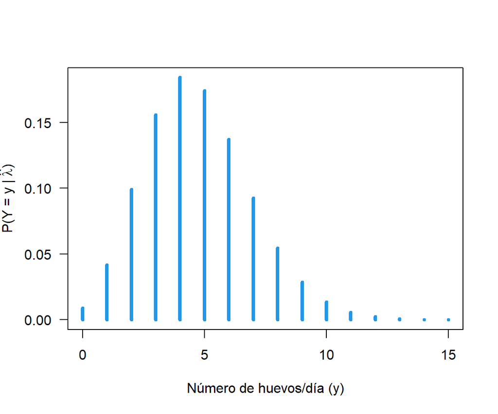

```r
## distribución de probabilidad basados en lambda
set.seed(123)
y <- 0:15
lambda <- predict(fit, newdata = x0, type = 'response')
proba <- dpois(y, lambda)
plot(y, proba, las = 1, type = 'h', col = 4,
     ylab = expression('P(Y = y | '*hat(lambda)*")"),
     xlab = 'Número de huevos/día (y)',
     lwd = 4)
```

### Simulación

A partir de los resultados obtenidos, es posible simular datos de una distribución Poisson con parámetro $\hat\lambda$ para cada galpón. Para ello utilizamos la función `rpois()`.

Supongamos que es de interés determinar el percentil 90 del número de huevos/galpón/día cuando $\hat{\lambda}|_{x_1=5, x_2=3, \text{diet}=\text{B}} = 4.72$.

Primero simulamos $B=10000$ observaciones de una distribución Poisson con parámetro $\hat\lambda = 4.72$

```r
## simulación
set.seed(1)
B <- 10000
ysim <- rpois(B, 4.72)
ysim[1:10]
```

```
 [1] 3 4 5 8 3 8 8 5 5 2
```

Finalmente, el percentil 90 puede calcularse como

```r
## percentil 95
quantile(ysim, probs = 0.9)
```

```
90%
  8
```

Por lo tanto, el 10% de nuestros galpones tendrían una producción de más de 7 huevos/día bajo las condiciones $x_1=5, x_2=3$ y la dieta `B`.

Si fuese de interés calcular $P(Y > 4 | \hat{\lambda})$, existen 2 posibilidades:

1. **Teóricamente.** En este caso calculamos

$$\begin{eqnarray}
P(Y > 4 | \hat\lambda = 4.72) &=& 1 - P(Y \leq 4 | \hat\lambda = 4.72) \\\nonumber
&=& 1 - \sum_{y=0}^4\frac{e^{-4.72}(4.72)^y}{y!}\nonumber\\
& = & 0.509
\end{eqnarray}$$

Esta probabilidad puede calcularse en `R` haciendo

```r
## cálculo probabilidad
1 - sum(dpois(0:4, 4.72))
```

```
[1] 0.5090842
```

2. **Via simulación.** Para esto usamos el objeto `ysim`, la función `mean` y el operador lógico `>`:

```r
## P(Y > 4 | lambda) utilizando simulación
mean(ysim > 4)
```

```
[1] 0.5055
```

Como era de esperarse, los resultados *no* coinciden, pero constituyen una muy buena aproximación :)

## Homework

**Fecha de entrega:** Abril 19, 2024.

En un proceso de ensamble se controlan la configuración (variable $x_1$, con niveles `A`, `B` y `C`) de la planta, el turno en el que se realiza el programa (variable $x_2$, con niveles `1`, `2` y `3`), y dos variables numéricas $x_3$ y $x_4$ de las que no se tiene mayor información. Al final del proceso se registra el número de piezas defectuosas que, desafortunadamente, se produjeron.

Los datos son los siguientes:

```
  piezas x1 x2 x3 x4
1      6  C T3 16 25
2      2  C T2 19 18
3      0  C T2 15 16
4      5  B T3 15 19
5      2  C T1 13 18
6      3  B T1 13 19
```

Así por ejemplo, al producir la unidad #5, se encontraron 2 piezas defectuosas por cada lote de 10 unidades.

**Preguntas**

1. Podríamos decir que la configuración de la planta y el turno en el que se produzan los lotes son *relevantes*? En qué condiciones $(x_3, x_4)$ el número de unidades defectuosas por lote tiende a cero?  
   *Nota*: En caso de que existan variables no significativas, reajuste el modelo.

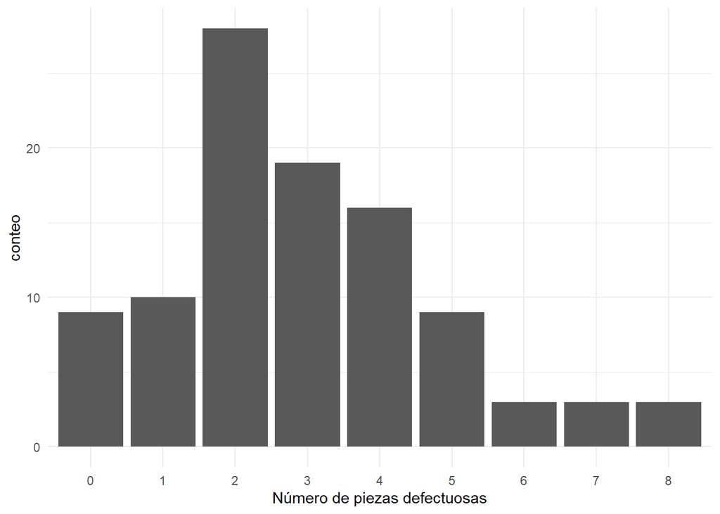

```r
## barplot con ggplot2
d0 <- as.data.frame(table(d$piezas))
ggplot(d0, aes(x = Var1, y = Freq)) +
  geom_bar(stat = 'identity') +
  xlab('Número de piezas defectuosas') +
  ylab('conteo') +
  theme_minimal()
```

**Modelo 1**

```r
fit <- glm(piezas ~ ., data = d, family = poisson())

# coeficientes estimados
summary(fit)
```

```
Call:
glm(formula = piezas ~ ., family = poisson(), data = d)

Deviance Residuals:
    Min       1Q   Median       3Q      Max
-2.6244  -0.7336  -0.1050   0.6101   2.4038

Coefficients:
            Estimate Std. Error z value Pr(>|z|)
(Intercept)  0.01887    0.40633   0.046   0.9630
x1B          0.13195    0.15083   0.875   0.3817
x1C          0.01069    0.15261   0.070   0.9442
x2T2         0.04775    0.14637   0.326   0.7442
x2T3         0.02173    0.15374   0.141   0.8876
x3           0.03447    0.02027   1.701   0.0890 .
x4           0.02431    0.01300   1.870   0.0615 .
---
Signif. codes:  0 '***' 0.001 '**' 0.01 '*' 0.05 '.' 0.1 ' ' 1

(Dispersion parameter for poisson family taken to be 1)

    Null deviance: 132.95  on 99  degrees of freedom
Residual deviance: 124.47  on 93  degrees of freedom
AIC: 406.28

Number of Fisher Scoring iterations: 5
```

```r
nullmodel <- glm(piezas ~ 1, data = d, family = poisson())

## LRT
lrtest(nullmodel, fit)
```

```
Likelihood ratio test

Model 1: piezas ~ 1
Model 2: piezas ~ x1 + x2 + x3 + x4
  #Df  LogLik Df  Chisq Pr(>Chisq)
1   1 -200.38
2   7 -196.14  6 8.4808     0.2049
```

Dado que este modelo no es mejor que un modelo nulo, se ajusta un nuevo modelo.

**Modelo 2**

```r
fit <- glm(piezas ~ x3 + x4, data = d, family = poisson())

# coeficientes estimados
summary(fit)
```

```
Call:
glm(formula = piezas ~ x3 + x4, family = poisson(), data = d)

Deviance Residuals:
    Min       1Q   Median       3Q      Max
-2.6572  -0.7711  -0.1750   0.6741   2.4495

Coefficients:
            Estimate Std. Error z value Pr(>|z|)
(Intercept)  0.03276    0.39162   0.084   0.9333
x3           0.03686    0.01941   1.899   0.0576 .
x4           0.02555    0.01232   2.075   0.0380 *
---
Signif. codes:  0 '***' 0.001 '**' 0.01 '*' 0.05 '.' 0.1 ' ' 1

(Dispersion parameter for poisson family taken to be 1)

    Null deviance: 132.95  on 99  degrees of freedom
Residual deviance: 125.49  on 97  degrees of freedom
AIC: 399.31

Number of Fisher Scoring iterations: 5
```

```r
nullmodel <- glm(piezas ~ 1, data = d, family = poisson())

## LRT
lrtest(nullmodel, fit)
```

```
Likelihood ratio test

Model 1: piezas ~ 1
Model 2: piezas ~ x3 + x4
  #Df  LogLik Df  Chisq Pr(>Chisq)
1   1 -200.38
2   3 -196.65  2 7.4576    0.02402 *
---
Signif. codes:  0 '***' 0.001 '**' 0.01 '*' 0.05 '.' 0.1 ' ' 1
```

Adicionalmente, se evalúa sobredispersión:

```r
## ajuste del modelo con enlace quasipoisson
fitq <- glm(piezas ~ ., data = d, family = quasipoisson)

## ahora estimamos la dispersión
summary(fitq)$dispersion
```

```
[1] 1.140447
```

```r
## prueba para el coeficiente de dispersión
dispersiontest(fit, trafo = 1)$p.value
```

```
[1] 0.3225026
```

```r
## cálculo de lambdahat estimadas
lambdahat <- predict(fit, type = 'response')

## ahora incluyamos lambdahat para los 5 primeros individuos
d <- data.frame(id = 1:NROW(d), d, lambdahat)
head(d, 5)
```

```
  id piezas x1 x2 x3 x4 lambdahat
1  1      6  C T3 16 25  3.530223
2  2      2  C T2 19 18  3.297134
3  3      0  C T2 15 16  2.703401
4  4      5  B T3 15 19  2.918806
5  5      2  C T1 13 18  2.642970
```

Respuestas 1:

- La configuración de la planta y el turno no son variables significativas para explicar la cantidad de piezas defectuosas. Por tanto, no son revelantes.
- El modelo ajustado es:

$$\log(\hat{\lambda}) = 0.03276 + 0.03686x_3 + 0.02555x_4$$

por tanto,

$$\begin{equation}
\hat\lambda = e^{0.03276 + 0.03686x_3 + 0.02555x_4}
\end{equation}$$

hipotéticamente,

Con esta ecuación se concluye que $\hat\lambda$ tiende a cero sólo si $x_3$ y $x_4$ disminuyen lo suficiente. No obstante, muy probablemente por la naturaleza del proceso esos valores no puedan ser menores de 0, por tanto, teóricamente $\hat\lambda$ puede tender a 1, y no a 0.

2. El Jefe de la Planta está convencido que al fabricar productos en las condiciones $x_3=15$ y $x_4=20$, el número promedio de unidades defectuosas por lote se reduce en un 40%, aproximadamente. Está usted de acuerdo? Si $x_4 = 20$, determine el valor de $x_3$ tal que el número promedio de unidades defectuosas por lote se reduce a sólo 2 unidades. Calcule la probabilidad de que, en estas condiciones, hayan 5 unidades defectuosas por lote.

Respuesta 2:

```r
# que pasa cuando (x3=15, X4=20) ?
x0 <- data.frame(x3 = 15, x4 = 20)
predict(fit, newdata = x0, type = 'response')
```

```
       1
2.994357
```

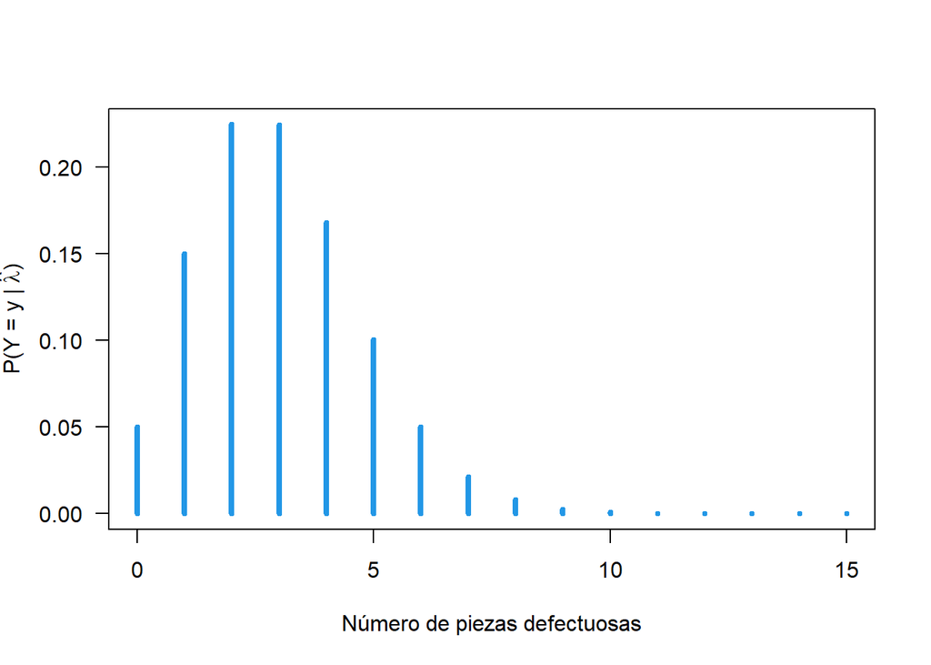

```r
## distribución de probabilidad basados en lambda
set.seed(123)
y <- 0:15
lambda <- predict(fit, newdata = x0, type = 'response')
proba <- dpois(y, lambda)
plot(y, proba, las = 1, type = 'h', col = 4,
     ylab = expression('P(Y = y | '*hat(lambda)*")"),
     xlab = 'Número de piezas defectuosas',
     lwd = 4)
```

Con esas condiciones, se esperan 2.99 piezas defectuosas y esto no representa una diferencia del valor esperado de la muestra de los datos: 2.95.

Para determinar x3, dado x4=20 y lambda=2

$$2 = e^{0.03276 + 0.03686x_3 + 0.02555(20)}$$
Por tanto,

$$ ln(2) = 0.03276 + 0.03686x_3 + 0.02555 * 20 \

0.03686x_3 = ln(2) - 0.03276 - 0.511 \

x_3 = 4.052826

$$

Y luego la predicción:

```r
x0 <- data.frame(x3 = 4.052826, x4 = 20)
predict(fit, newdata = x0, type = 'response')
```

```
       1
2.000174
```

Finalmente, para estimar la probabilidad de que la cantidad de piezas defectuosas sea 5 dado $\hat\lambda = 2$

```r
dpois(5, 2)
```

```
[1] 0.03608941
```

O simulando:

```r
## simulación
set.seed(1)
B <- 100000
ysim <- rpois(B, 2)
mean(ysim == 5)
```

```
[1] 0.03569
```

## Recursos adicionales

1. [Regression](https://cran.r-project.org/web/packages/pscl/vignettes/countreg.pdf) Models for Count Data in `R`
2. Sección [4.3](https://jivelez.github.io/book-adii/glm.html#regresi%C3%B3n-poisson) de [*Modelos de Regresión: Una aproximación práctica con R*](https://jivelez.github.io/book-adii/)
3. Poisson Regression in [SMDA](https://stats.oarc.ucla.edu/r/dae/poisson-regression/)
4. Chapter [4](https://bookdown.org/roback/bookdown-BeyondMLR/ch-poissonreg.html) de [*Beyond Multiple Linear Regression*](https://bookdown.org/roback/bookdown-BeyondMLR/) por [Paul Roback](https://www.stolaf.edu/profile/roback) & [Julie Legler](https://en.wikipedia.org/wiki/Julie_Legler)